# R plots by Pawel Mrozowski

# Overview

```
##      X1965     X1966          X1967          X1968          X1969
##  Min.   :0    Mode:logical   Mode:logical   Mode:logical   Mode:logical
##  1st Qu.:0    NA's:275       NA's:275       NA's:275       NA's:275
##  Median :0
##  Mean   :0
##  3rd Qu.:0
##  Max.   :0
##  NA's   :79
##      X1970     X1971          X1972          X1973          X1974
##  Min.   :0    Mode:logical   Mode:logical   Mode:logical   Mode:logical
##  1st Qu.:0    NA's:275       NA's:275       NA's:275       NA's:275
##  Median :0
##  Mean   :0
##  3rd Qu.:0
##  Max.   :0
##  NA's   :79
##      X1975        X1976        X1977        X1978        X1979
##  Min.   :0    Min.   :0    Min.   :0    Min.   :0    Min.   :0
##  1st Qu.:0    1st Qu.:0    1st Qu.:0    1st Qu.:0    1st Qu.:0
##  Median :0    Median :0    Median :0    Median :0    Median :0
##  Mean   :0    Mean   :0    Mean   :0    Mean   :0    Mean   :0
##  3rd Qu.:0    3rd Qu.:0    3rd Qu.:0    3rd Qu.:0    3rd Qu.:0
##  Max.   :0    Max.   :0    Max.   :0    Max.   :0    Max.   :0
##  NA's   :79   NA's   :79   NA's   :79   NA's   :79   NA's   :79
##      X1980             X1981             X1982             X1983
##  Min.   :    0.0   Min.   :    0.0   Min.   :    0.0   Min.   :    0.0
##  1st Qu.:    0.0   1st Qu.:    0.0   1st Qu.:    0.0   1st Qu.:    0.0
##  Median :    0.0   Median :    0.0   Median :    0.0   Median :    0.0
##  Mean   :  119.8   Mean   :  326.1   Mean   :  520.6   Mean   :  767.3
##  3rd Qu.:    0.0   3rd Qu.:    0.0   3rd Qu.:    0.0   3rd Qu.:    0.0
##  Max.   :23482.0   Max.   :28278.0   Max.   :33880.0   Max.   :42226.0
##  NA's   :79        NA's   :80        NA's   :80        NA's   :81
##      X1984           X1985            X1986            X1987
##  Min.   :    0   Min.   :     0   Min.   :     0   Min.   :      0
##  1st Qu.:    0   1st Qu.:     0   1st Qu.:     0   1st Qu.:      0
##  Median :    0   Median :     0   Median :     0   Median :      0
##  Mean   : 1663   Mean   :  3930   Mean   :  7514   Mean   :  13326
##  3rd Qu.:    0   3rd Qu.:     0   3rd Qu.:     0   3rd Qu.:      0
##  Max.   :91600   Max.   :340213   Max.   :681825   Max.   :1230855
##  NA's   :83      NA's   :84       NA's   :82       NA's   :84
```

[output cut: 49 more lines]

```
##  Min.   :        0   Min.   :        0   Min.   :     1000
##  1st Qu.:   380418   1st Qu.:   600000   1st Qu.:   668237
##  Median :  2501140   Median :  3394016   Median :  4081632
##  Mean   : 16558541   Mean   : 19928682   Mean   : 22870061
##  3rd Qu.:  9932983   3rd Qu.: 11684479   3rd Qu.: 13227396
##  Max.   :547306000   Max.   :641245000   Max.   :747214000
##  NA's   :73          NA's   :74          NA's   :73
##      X2010               X2011
##  Min.   :     1600   Min.   :     2130
##  1st Qu.:   956924   1st Qu.:  1324654
##  Median :  4909666   Median :  6426526
##  Mean   : 26403896   Mean   : 31216042
##  3rd Qu.: 14040479   3rd Qu.: 18129152
##  Max.   :859003000   Max.   :986253000
##  NA's   :75          NA's   :85
```

```
##                       X1965 X1966 X1967 X1968 X1969 X1970 X1971 X1972
## Abkhazia                 NA    NA    NA    NA    NA    NA    NA    NA
## Afghanistan               0    NA    NA    NA    NA     0    NA    NA
## Akrotiri and Dhekelia    NA    NA    NA    NA    NA    NA    NA    NA
## Albania                   0    NA    NA    NA    NA     0    NA    NA
## Algeria                   0    NA    NA    NA    NA     0    NA    NA
## American Samoa            0    NA    NA    NA    NA     0    NA    NA
##                       X1973 X1974 X1975 X1976 X1977 X1978 X1979 X1980
## Abkhazia                 NA    NA    NA    NA    NA    NA    NA    NA
## Afghanistan              NA    NA     0     0     0     0     0     0
## Akrotiri and Dhekelia    NA    NA    NA    NA    NA    NA    NA    NA
## Albania                  NA    NA     0     0     0     0     0     0
## Algeria                  NA    NA     0     0     0     0     0     0
## American Samoa           NA    NA     0     0     0     0     0     0
##                       X1981 X1982 X1983 X1984 X1985 X1986 X1987 X1988
## Abkhazia                 NA    NA    NA    NA    NA    NA    NA    NA
## Afghanistan               0     0     0     0     0     0     0     0
## Akrotiri and Dhekelia    NA    NA    NA    NA    NA    NA    NA    NA
## Albania                   0     0     0     0     0     0     0     0
## Algeria                   0     0     0     0     0     0     0     0
## American Samoa            0     0     0     0     0     0    NA    NA
##                       X1989 X1990 X1991 X1992 X1993 X1994 X1995 X1996
## Abkhazia                 NA    NA    NA    NA    NA    NA    NA    NA
## Afghanistan               0     0     0     0     0     0     0     0
## Akrotiri and Dhekelia    NA    NA    NA    NA    NA    NA    NA    NA
## Albania                   0     0     0     0     0     0     0  2300
## Algeria                   0   470  4781  4781  4781  1348  4691 11700
## American Samoa           NA     0     0   700   900  1200  1250  1300
##                       X1997 X1998 X1999 X2000  X2001  X2002   X2003
## Abkhazia                 NA    NA    NA    NA     NA     NA      NA
## Afghanistan               0     0     0     0      0  25000  200000
## Akrotiri and Dhekelia    NA    NA    NA    NA     NA     NA      NA
## Albania                3300  5600 11008 29791 392650 851000 1100000
## Algeria               17400 18000 72000 86000 100000 450244 1446927
## American Samoa         1400  1500  1800  1992   2156   2036    2100
##                         X2004    X2005    X2006    X2007    X2008    X2009
## Abkhazia                   NA       NA       NA       NA       NA       NA
## Afghanistan            600000  1200000  2520366  4668096  7898909 10500000
## Akrotiri and Dhekelia      NA       NA       NA       NA       NA       NA
## Albania               1259590  1530244  1909885  2322436  1859632  2463741
## Algeria               4882414 13661355 20997954 27562721 27031472 32729824
## American Samoa           2250       NA       NA       NA       NA       NA
##                          X2010    X2011
## Abkhazia                    NA       NA
## Afghanistan           13000000 17558265
## Akrotiri and Dhekelia       NA       NA
## Albania                2692372  3100000
## Algeria               32780165 35615926
## American Samoa              NA       NA
```

# Univariate Analysis

Firstly we try to take a look on quantity of phones in all dataset

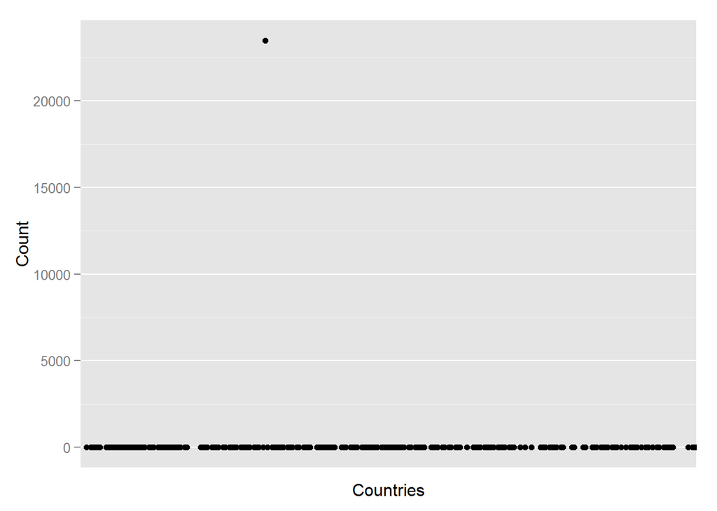

There is one interesting point, we try to find what is this country by taking top data from dataframe for this year

We must find the name of country with max value and value itself:

First we check which row has maximum value

```
## [1] 76
```

the value is

```
## [1] 23482
```

and what is the conutry

```
## [1] Finland
## 275 Levels: Ă…land Abkhazia Afghanistan Akrotiri and Dhekelia ... Zimbabwe
```

So we have confirmation that in fact the only country in the dataset that had cell phones was Finland.

We move to year 2010 and do some visualization. Having value points for year 2010 we want to show average value for this year on the plot . First we calculate average value for year 2010.

then we choose year 2010

```
##    X2010
## 19202834
```

Now we add this as layer to plot.

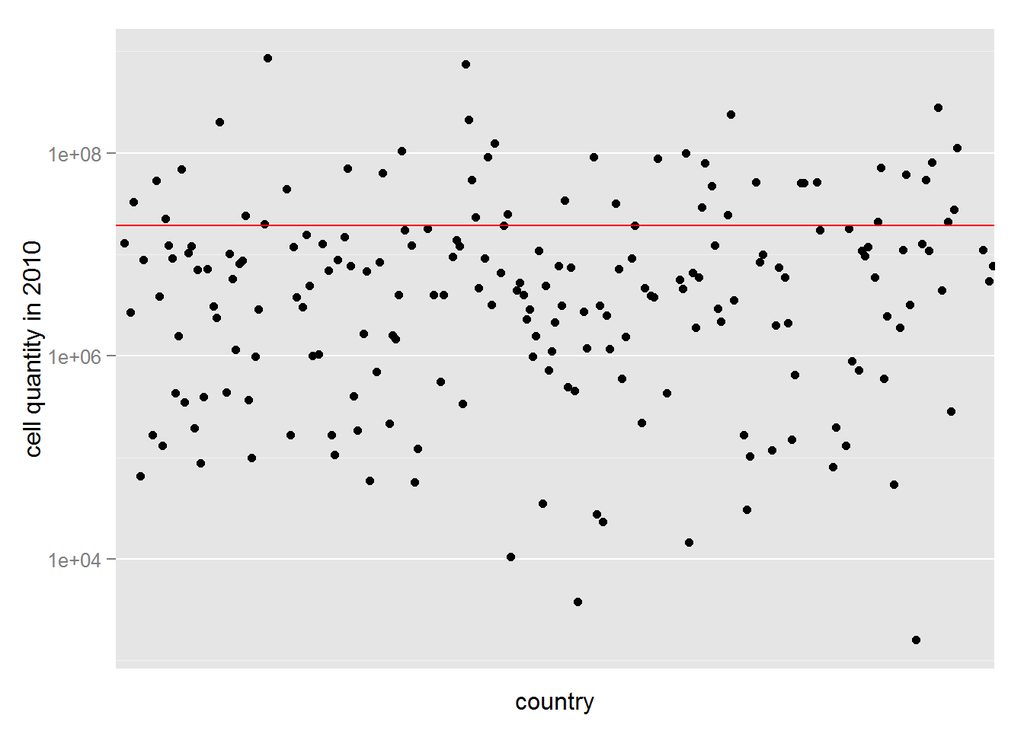

Now last thing we want to know is how many countries have quantity above average.

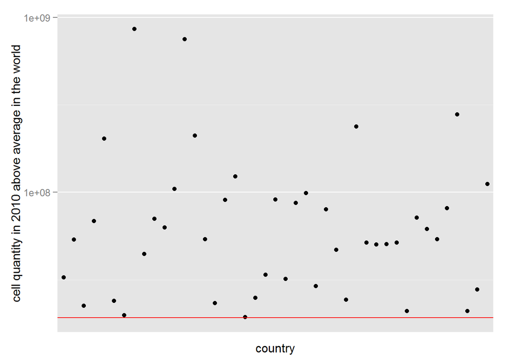

```
##     Mobile.cellular.subscriptions..total.number
## 5                                       Algeria
## 11                                    Argentina
## 14                                    Australia
## 19                                   Bangladesh
## 30                                       Brazil
## 38                                       Canada
## 44                                        Chile
## 45                                        China
## 48                                     Colombia
## 66                                        Egypt
## 77                                       France
## 83                                      Germany
## 102                                       India
## 103                                   Indonesia
```

[output cut: 29 more lines]

# Bivariate Analysis

Here we begin bivariate analysis. The structure of dataset is simple. From one side we have Countries, from the other we have rows/columns with cell phone quantities since 1965 till 2011 as separated values. So actually to begin analysis we must create some new variables like average/total amount by binding some data.We are going to compare overall data set characteristics with my country Poland.

We want to answer a few questions: 1- how the total amount of phones changed over time 2- how the total amount of phones changed in Poland and compare it with global analysis 3- how is the relation between world trend to my country’s trend

Since the data is in separated columns we must build two variables: years and total

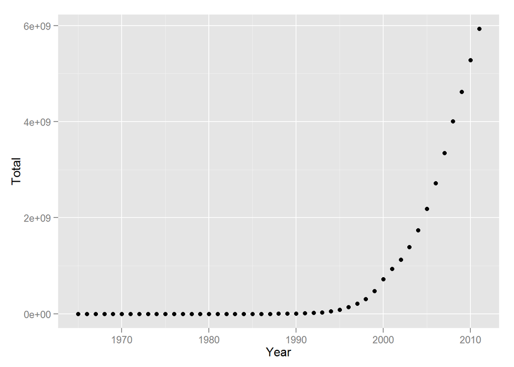

Now we can narrow this growth to one country, e.g. Poland and compare this with total value for all dataset.

```
##    Poland
## 370378624
```

Now let’s visualize cell quantity in Poland.

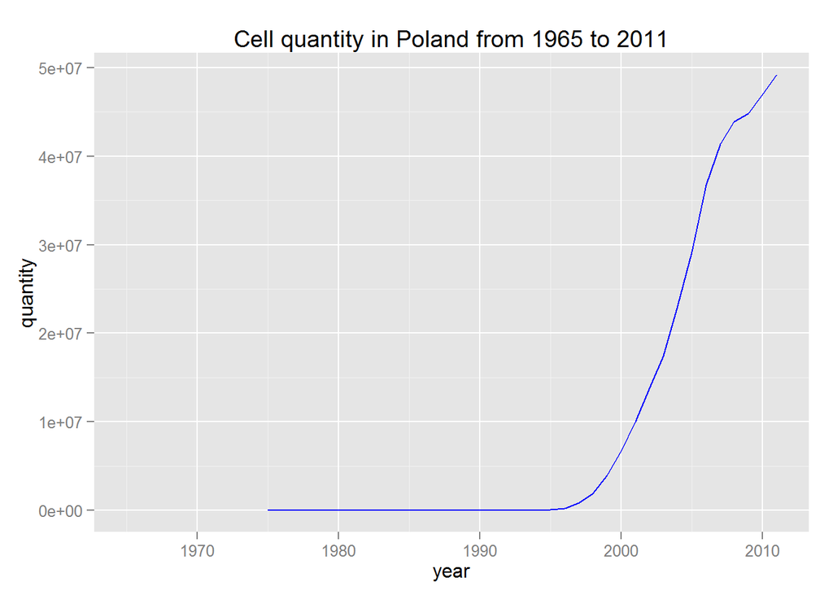

We can see that significant increase occured in 1995 till 2005.

Now let’s change scale to see it better.

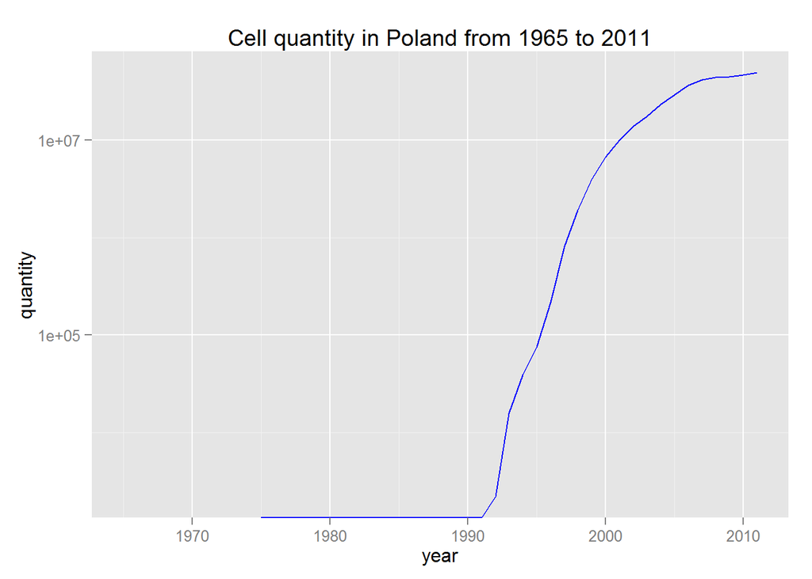

We can now compare both values and avarage in the world: plots on one graph to see how Poland is related to overall total number

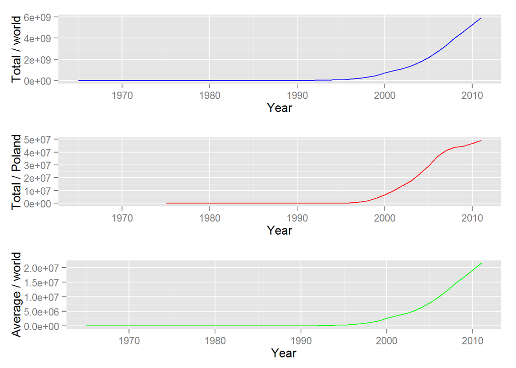

We can see that the shape is different and the increase of phones tends to slow down from 2008 and 2009 . Now let’s change Y scale in the same way we did before.

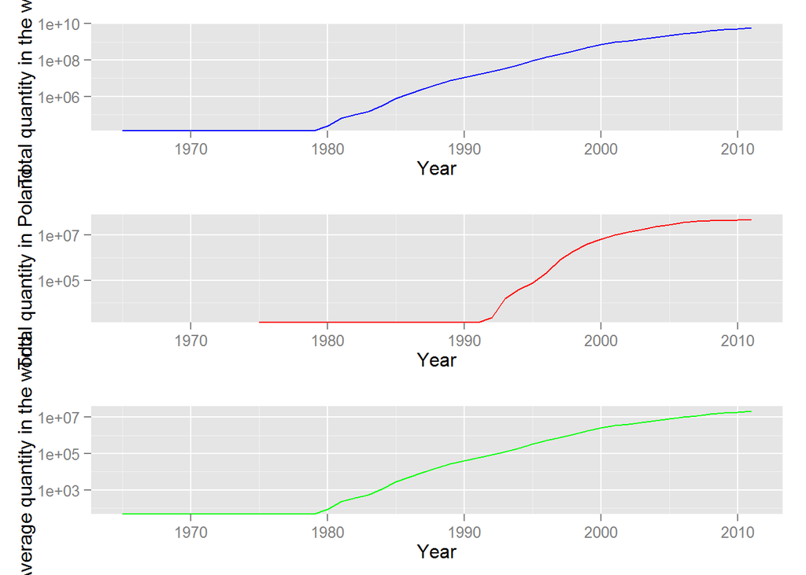

We can see that the shape of function is similar but is relatively x times less (obvious) but also started about 10 years after world’s trend, which is justified taking into account the political aspect of Poland. Year 1989 is actually the fists year of capitalism and end of communism, so country coud benefit from hith tech that was forbidden before.

Now I want to compare Poland’s ratio in increase in last 5 years vs the country with top number of cells in 2011. This can help to understand in Polish market is actually growing fast .

First lets find the country with top nb of phones totally in 2011. We can expect this to be one from China, India, Usa.

```
## [1] 986253000
```

```
##       X1965 X1966 X1967 X1968 X1969 X1970 X1971 X1972 X1973 X1974 X1975
## China     0    NA    NA    NA    NA     0    NA    NA    NA    NA     0
##       X1976 X1977 X1978 X1979 X1980 X1981 X1982 X1983 X1984 X1985 X1986
## China     0     0     0     0     0     0     0     0     0     0     0
##       X1987 X1988 X1989 X1990 X1991  X1992  X1993   X1994   X1995   X1996
## China   700  3227  9805 18319 47544 176943 638000 1568000 3629000 6853000
##          X1997    X1998    X1999    X2000     X2001     X2002     X2003
## China 13233000 23863000 43296000 85260000 144820000 206005000 269953000
##           X2004     X2005     X2006     X2007     X2008     X2009
## China 334824000 393406000 461058000 547306000 641245000 747214000
##           X2010     X2011
## China 859003000 986253000
```

so we confirm it is China. Now let’s calculate ratios:

Now we can plot China and Poland. (first we will add X axis to make our plots easier and cleaner )

```
##                             V180
## pf$X2006/pf$X2005      1.2598560
## ratio2007to2006        1.1263645
## ratio2008to2007        1.0613111
## ratio2009to2008        1.0200396
## ratio2010to2009        1.0478831
## ratio2011to2010        1.0478762
## ratio2011to2010tablets 0.5811255
## ratio2010to2009tablets 3.0019108
```

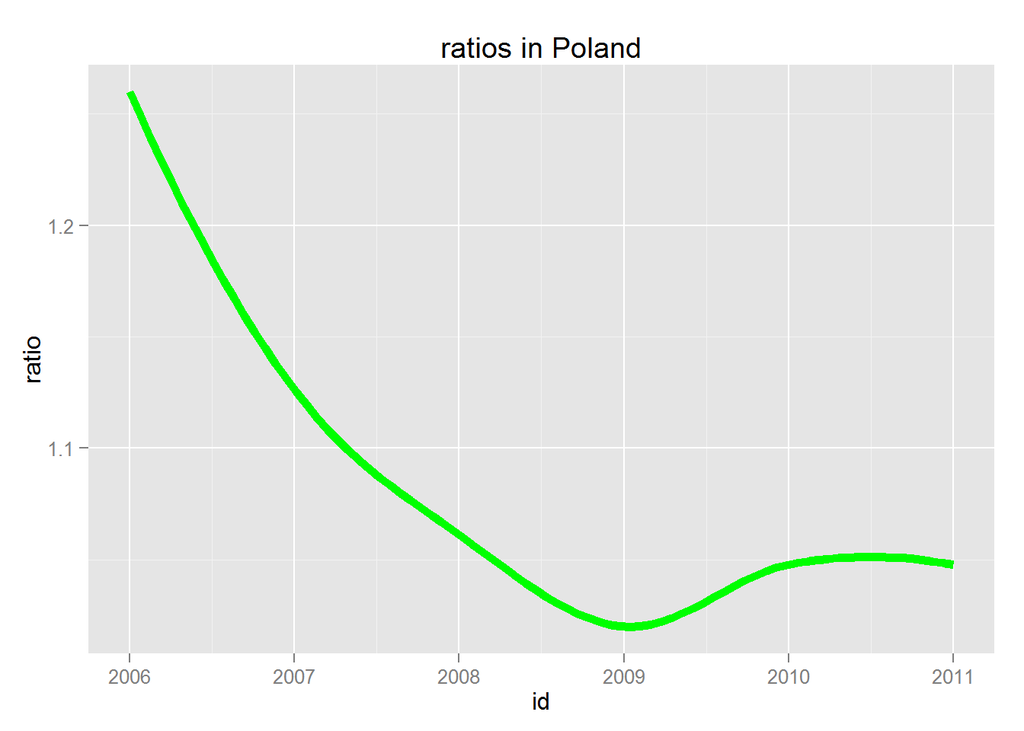

We can see that ratio of phones each year decreases almost to 1, so we see that the market is stabilizing and becomes full.

```
##                             V45
## pf$X2006/pf$X2005      1.171965
## ratio2007to2006        1.187065
## ratio2008to2007        1.171639
## ratio2009to2008        1.165255
## ratio2010to2009        1.149608
## ratio2011to2010        1.148137
## ratio2011to2010tablets 0.881893
## ratio2010to2009tablets 4.366981
```

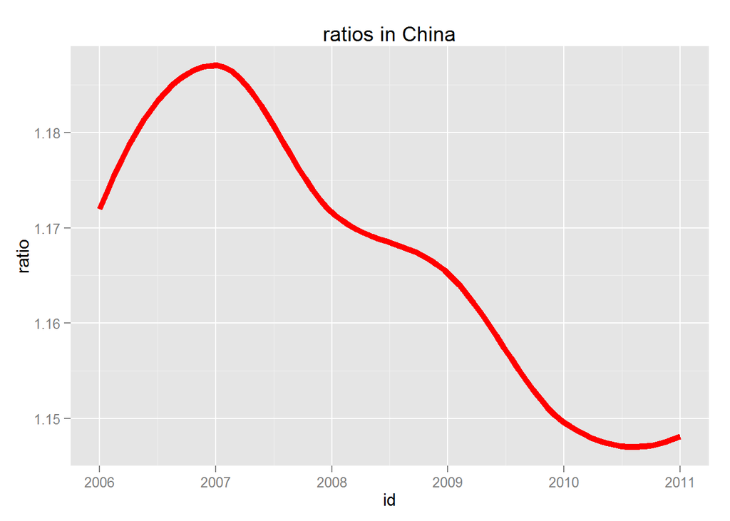

If we take a look what is in China we see that the market was growing extraordinary in 2007 in comparison to 2006 but till 2011 this increase actually stopped and tends to grow one again.

But how is the relation between those two:

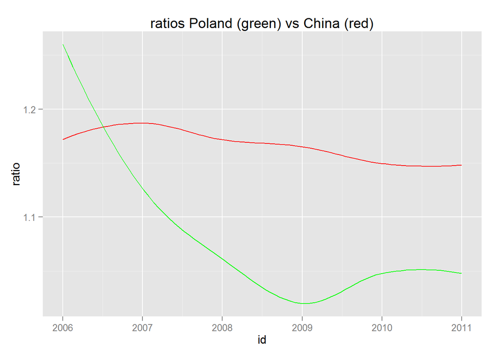

We can see that China still has ratio higher than 1, thus we can expect steady growth in the future.

Finally we want to see the relation of ratios from 2005 to 2011 for all countries in the dataset. This gives an overview how previous ratio (year before) is related to the ratio in next year , if tendency is generally dropping or rising as a reaction to overall marked need.

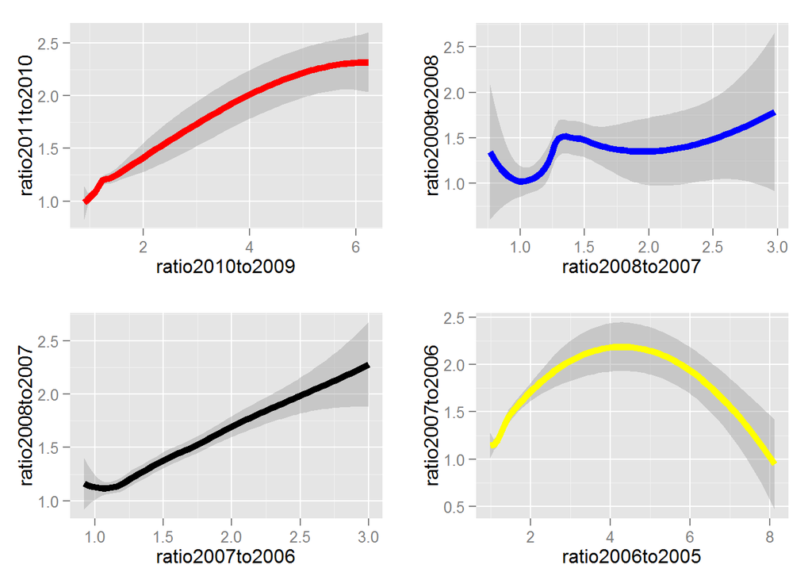

The shape of functions can be very different. All is related to global market trends, growths and market collapses. From here we can try to find out the ratio trends related to new technologies available like incorporation of 3G networks or any other global market events (related to globalization). To be more precisely we would need to have better dataset. Taking a look at the plots , for example, on comparison of cell phone quantity ratios from 2008/2007 to 2007/2006 we can see a straigth line with more spread above 200% and very big spread near 300%. This indicates that there was a growth in overall because of the ratios more than 1, but “mapping” between higher ratio (above 2,5 and below 3) in 2007/2006 to next year was actually worse, since oscillated between 170% and 260% tops. Ratios that were between 120% to 180% did not oscillated much, but were “mapped” to actually lower values so the markets were following world’s trend to fill the market capacity asymptotically to some point not shown in this dataset.

# Multivariate

In this section we want to make similar analysis like in bivariate secion, but in relation to tables quantity sold in 2009/2010/2011.

Having some data (added manually with some randomness) about tablets in the last 3 years, we want to answer question like:

- what is the relationship between cell quantity ratios 2011/2010 vs 2010/2009 and it’s relation to tablets ratio 2011/2010 in colour and 2010/2009 in points sizes.

Let’s assume (based on added data) that the general trend is increasing.

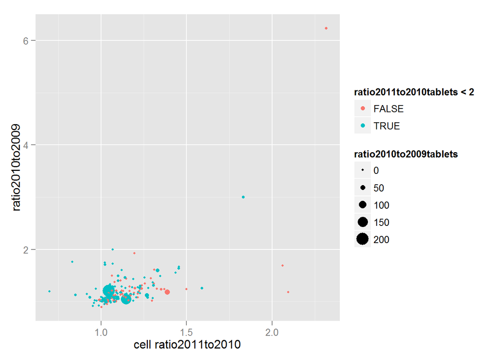

Now we want to exclude from plot some exeptional values since we are interester on general trend.

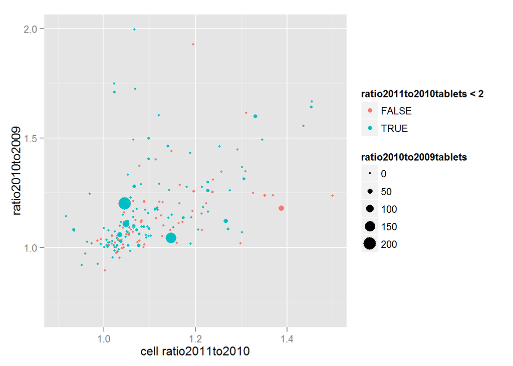

We can see that the general idea of the plot (comparison of cell quantity ratios in concurrent years in relation to tables ration in 2011/2010 and 2010/2009) shows concentration of highest values in tablets quantity increase between 100-120% on X axis and 100-125% on Y. These are ratios of tablet quantity smaller than 200% in last year. We can also see rather equal number of points representing countries , that have the tablet ratio less than 200% to more than 200% so equilibrium is kept. Conclusion may be that the market started to grow but there was no boom yet.

# Final Plots and Summary

### Plot One

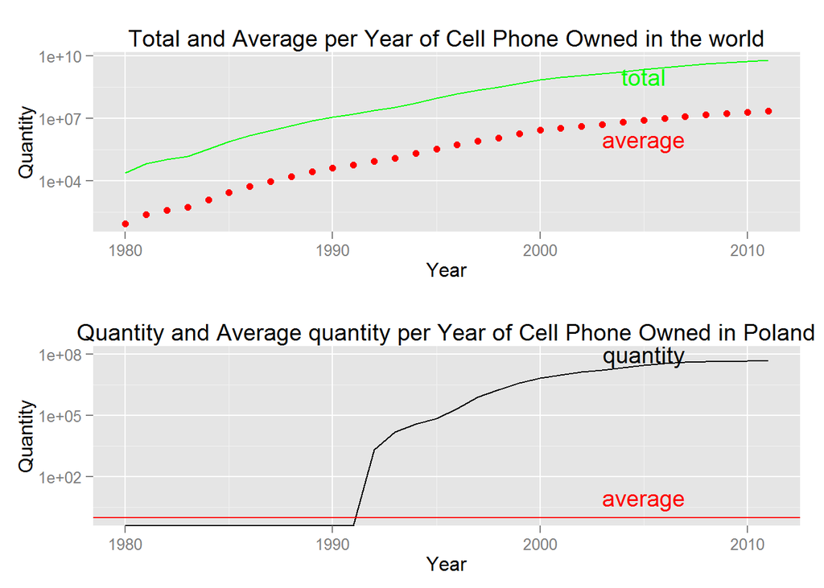

### Description One

First plot’s task is to show relation of Average and Total amount of cell phones in the world related to Poland : average and total quantityin the world. What was the most importand finding on the top plot is that in fact the year 1980 was the first one when first cell phones appeared as a technology. Since then we can see the steady growth (but we must remebmer this is logarithmic scale). On the other hand we depicted the same values for Poland, since our question was, if the growth of cells in Poland looks the same or different. We have also confirmed that western technology was not available in Poland because of communism and that the revolution of mobile phones began actually 10 years after.

### Plot Two

```
##    Min. 1st Qu.  Median    Mean 3rd Qu.    Max.    NA's
##  0.6975  1.0340  1.0760  1.1260  1.1660  2.3150      86
```

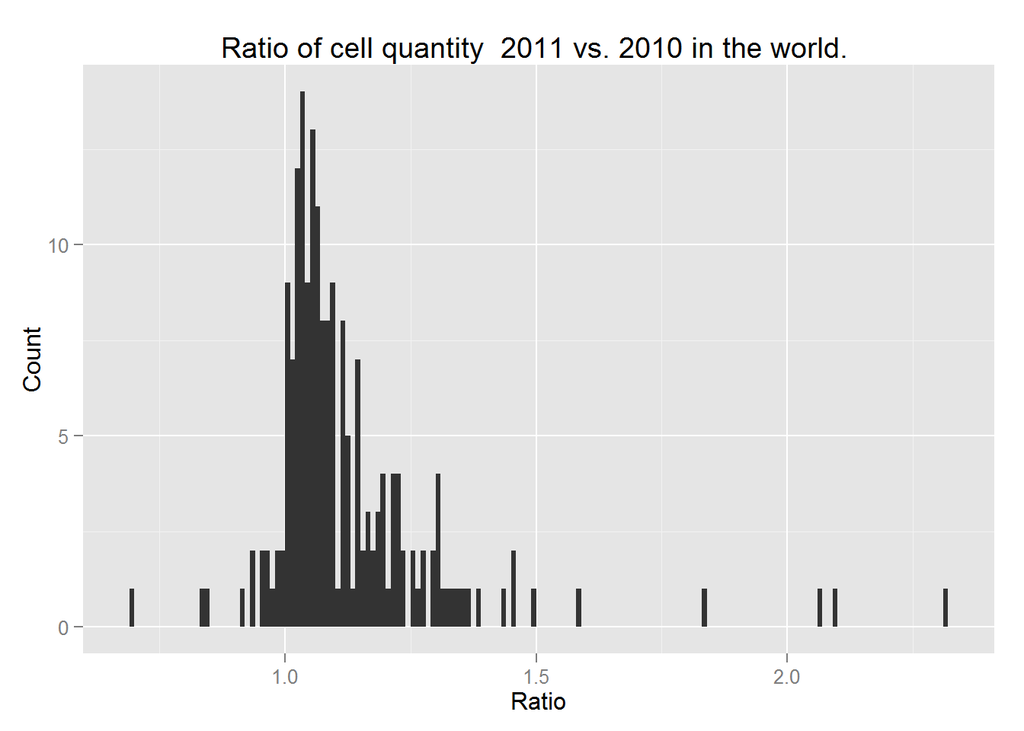

### Plot Three

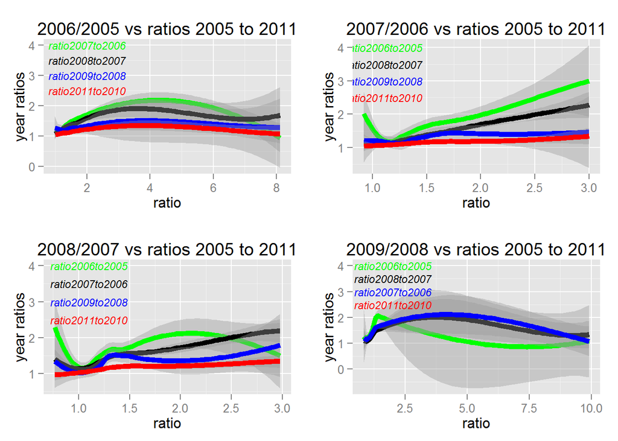

### Description Three

The final plot in this section relates albo to very interesting “ratio” idea indicator, that can show us what was the country/world reaction to the cell phones market over time. I want to depict on one plot many ratios, but in a different way (also from years 2005 to 2011): by taking ratio 2006/2005 and compare it with ratios obtained for the next years. The same operation will be done for next years.

We can see mamy interesting events like:

-on the second plot almost all lines are non-decreasing taking into account Xaxis values higher that 120%, also Y axis reaches 400%, more than X

-on the third plot we can see that around 110% all plots are close to each other having a bump between 125% and 135%.

-ont the fourth plot we can see great spread of values, which indicates some “boom” in cell quantity (or wrong value)

# Reflection

By anlysing the data we can see the very beginning of cellular telephony in 80’ growing steadily with a boom in late 90’ and in the next decade. Poland was 10 years behind world’s trend until 1989 . Today Poland is actually the leader of LTE technology in Europe by having the most users and signal coverage. First difficulty I had was related to the data itself.

I had to create csv file with header and import it properly to R. Structure shows that this is actually a spreadsheet of values. The relation before the data seems to be none or limited. In order to begin finding patterns the data had to be groupped together, visualized as a combination of features, not features alone. Since the dataset has actually rather simple structure, some of the characteristics has to be obtained by combining the data together. Finally to create more interesting analysis some of the data had to be added.

The last plot can be a great starting point for more thorough analyse. This type of plot was chosen because it is easy to read and can show not only main dependency between ratios but also a spread of values in relation one to another. It is also not obvious to interpret since growing values do not necessary mean increase/decrease of cell phones in the world or chosen country. This can help to identify some trends. Generally speaking the markets start to become saturated and that producers must change strategy to sell more by offering new services available only to modern smartphones or better prices to users, so they are willing to change old phone even if they do not need because it is still working, or maybe focus on diffenert devices like phablets and/or mobile tablet-laptop-phone.

# Resources

R CookBook

http://www.cookbook-r.com

http://www3.nd.edu/~steve/computing_with_data/11_geom_examples/ggplot_examples.html

http://www.ademcan.net

http://www.cookbook-r.com/Graphs/Axes_%28ggplot2%29/

http://www.r-bloggers.com/ggplot2-tutorial/

http://ggplot2.org/book/qplot.pdf

http://docs.ggplot2.org/0.9.3/annotate.html